# tutorial ggplot2

Talita Lôbo

**GGplot2** é um pacote de visualização de dados que pode ser utilizado junto à ferramenta R. Esta biblioteca é um conjunto de componentes independentes que podem ser aplicados de várias formas, construindo gráficos de maneira incremental.

*“A general scheme for data visualization which breaks up graphs into semantic components such as scales and layers. Ggplot2 can serve as a replacement for the base graphics in R and contains a number of defaults for web and print display of common scales”.*

### Instalação e carregamento do pacote

A instalação e utilização da biblioteca no RStudio é feita da seguinte maneira, respectivamente (retire a #):

```r
#install.packages("ggplot2")

#library(ggplot2)
```

### Criando o primeiro plot

Neste primeiro momento utilizaremos uma base de dados padrão do R, Íris - para mais informações: help(iris).

```r
# Carrega a base de dados em iris
iris <- iris

# Breve sumário sobre os dados
summary(iris)
```

```
##   Sepal.Length    Sepal.Width     Petal.Length    Petal.Width          Species
##  Min.   :4.300   Min.   :2.000   Min.   :1.000   Min.   :0.100   setosa    :50
##  1st Qu.:5.100   1st Qu.:2.800   1st Qu.:1.600   1st Qu.:0.300   versicolor:50
##  Median :5.800   Median :3.000   Median :4.350   Median :1.300   virginica :50
##  Mean   :5.843   Mean   :3.057   Mean   :3.758   Mean   :1.199
##  3rd Qu.:6.400   3rd Qu.:3.300   3rd Qu.:5.100   3rd Qu.:1.800
##  Max.   :7.900   Max.   :4.400   Max.   :6.900   Max.   :2.500
```

Diferente de outras bibliotecas **ggplot2**, não é verborrágico e a geração dos gráficos utiliza o conceito de camadas. Podemos ‘guardar’ gráficos em variáveis, adicionar outras camadas, modificar as já existentes e finalmente, plotar o gráfico.  
Para construção dos plots dispomos de elementos gráficos tais como:

- Linhas
- Segmentos de linhas
- Pontos
- Barras
- Textos

E cada um desses elementos possuem suas próprias características (aesthetics). Por exemplo:

- Ponto - **geom_point()**
  - shape - triângulo, círculo, quadrado, …
- Linhas - **geom_line()**
  - type - fechada, tracejada, …
  - weight

Então, simplesmente temos:

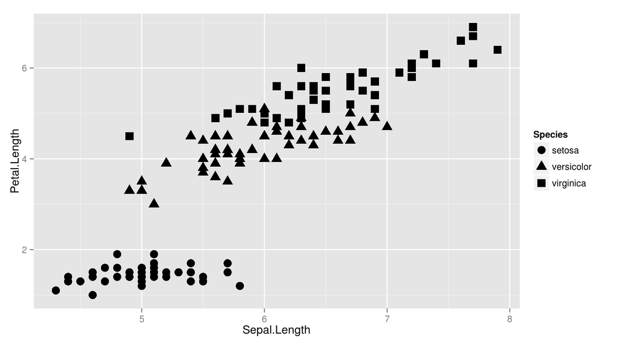

```r
a <- ggplot(data=iris, aes(x=Sepal.Length, y=Petal.Length, shape = Species))
a <- a + geom_point(size=4)
# Plot do gráfico
a
```

Explicando melhor o comando acima:

- a <- … : ‘Guarda’ em a o objeto do plot;
- ggplot(data=iris, …): Inicia o objeto ggplot e define a base de dados a ser usada naquele plot;
- aes (Aesthetics): Descreve como as variáveis dos dados são mapeadas para elementos visuais. Neste caso o eixo x representará o Tamanho da Sépala (Sepal.Length), o eixo y o Tamanho da Pétala (Petal.Length) e a forma do ponto (shape) dependerá da Espécie (Specie) da flor;
- geom_point(…): Espeficica o tipo de gráfico que estamos construindo, neste caso um gráfico de pontos ou gráfico de dispersão - scatterplot;
- Utilizando o operador ‘+’ pode-se adicionar camadas ao objeto ggplot criado acima;

> “The first argument to ggplot() is a data frame (it must be a data frame), and its second argument is aes(). It might be best not to think of aes() as its own function, but rather as a special way of defining data-to-aesthetic mappings.”

Como incremento do gráfico acima podemos também definir labels para os eixos, cores, titulo, dentre outras propriedades.

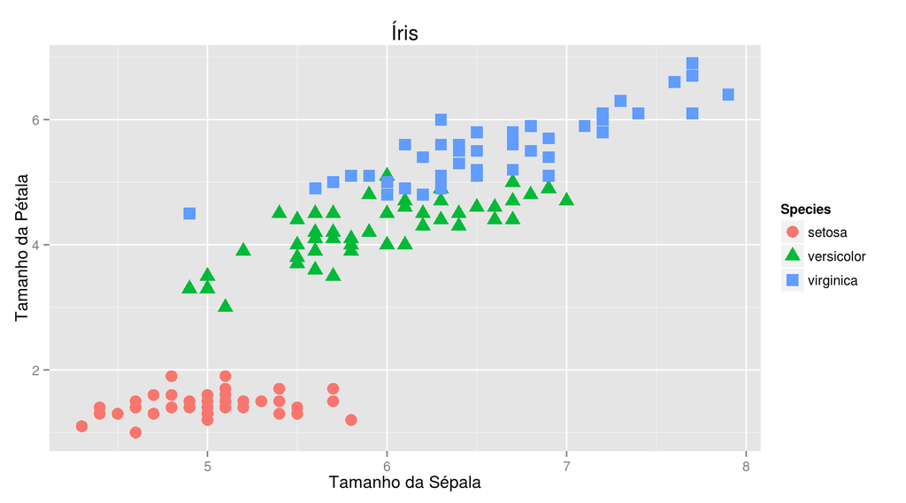

```r
# ggplot(data=iris, aes(x=Sepal.Length, y=Petal.Length, shape = Species)) + geom_point(size=4, aes(colour=Species)) + xlab("Tamanho da Sépala") + ylab("Tamanho da Pétala") + ggtitle("Íris")

# Ou

# ggplot(data=iris, aes(x=Sepal.Length, y=Petal.Length, shape = Species, col = Species)) + geom_point(size=4, aes(colour=Species)) + xlab("Tamanho da Sépala") + ylab("Tamanho da Pétala") + ggtitle("Íris")

# No caso em que utilizemos várias camadas como a 'geom_point()' é necessário que informemos novamente quem serão os eixos x e y, por exemplo:

ggplot(iris) + geom_point(aes(x=Sepal.Length, y=Petal.Length)) + geom_point(size=4, aes(x=Sepal.Length, y=Petal.Length, col=Species, shape=Species)) + xlab("Tamanho da Sépala") + ylab("Tamanho da Pétala") + ggtitle("Íris")
```

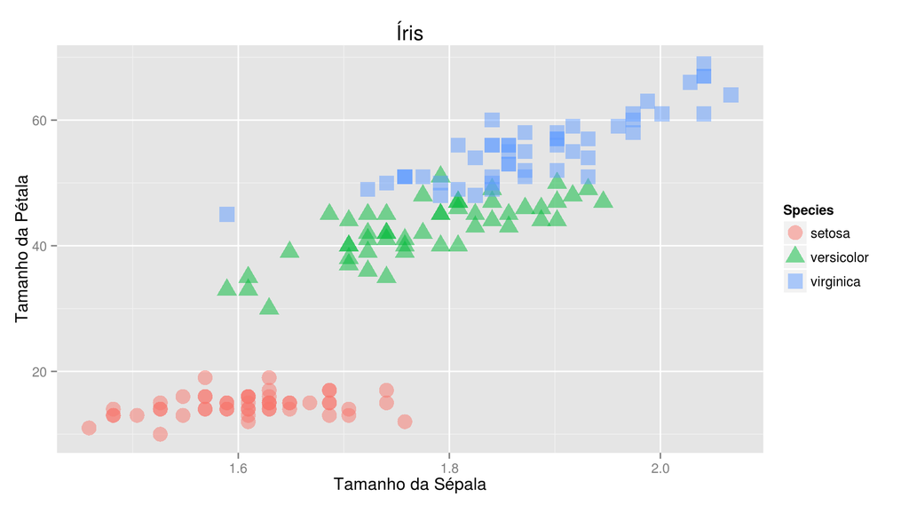

```r
# Podemos até mesmo transformar variáveis diretamente no próprio ggplot2 (repare na escala)

ggplot(iris) + geom_point(aes(x=log(Sepal.Length), y=Petal.Length*10, shape = Species, colour=Species), size=5, alpha=0.5) + xlab("Tamanho da Sépala") + ylab("Tamanho da Pétala") + ggtitle("Íris")
```

Outra forma de analisar nossos dados é separá-los em gráficos distintos, para tanto podemos utilizar **facets**, isso nos dará vários plots.

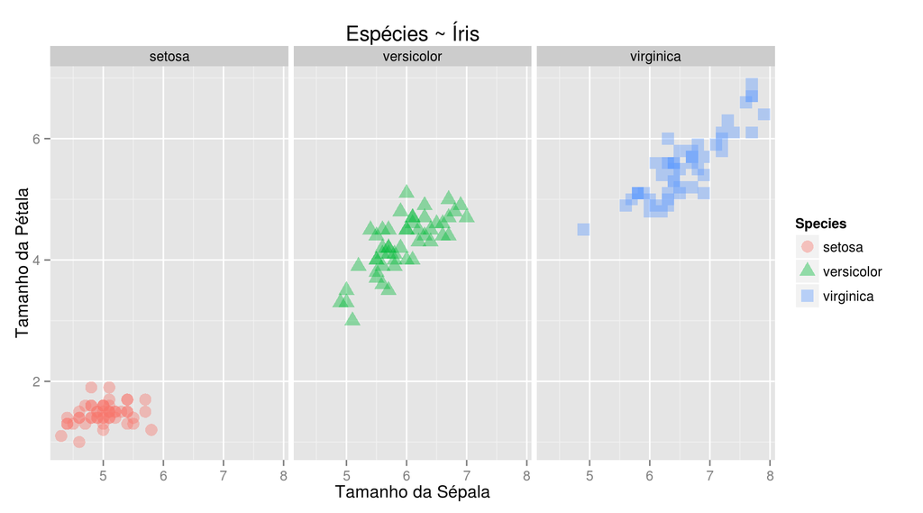

```r
ggplot(iris, aes(x=Sepal.Length, y=Petal.Length, col=Species, shape=Species)) + geom_point(size=4, alpha=0.4) + facet_wrap(~Species) + xlab("Tamanho da Sépala") + ylab("Tamanho da Pétala") + ggtitle("Espécies ~ Íris")
```

Acima demonstramos apenas como se dá a construção de gráficos que não necessariamente passam alguma informação.  
*Na construção de gráficos é importante identificar qual pergunta queremos responder com aquela representação e quais informações da base de dados utilizar para melhor responder essa pergunta. A escolha do(s) elemento(s) geométrico(s) utilizados deverá ser baseada na resposta que desejamos proporcionar.*  
Nos exemplos abaixo veremos outros tipos de gráfico e como construí-los.